# Jefferson

Topics that will be discussed in this summary report for Jefferson County are

- Demographic Characteristics
  - Population growth from 1970 to 2020;
  - population density
  - sex, race, and age
  - educational level of the adult population
  - housing characteristics in terms of age of the housing stock and type of tenure
- Economic Characteristics
  - family income, household income, per capita income,
  - poverty status of families;
  - employment classification according to industry;
  - labor force by place of work and commuting patterns;

For more details on the data used, please see the Data Description tab.

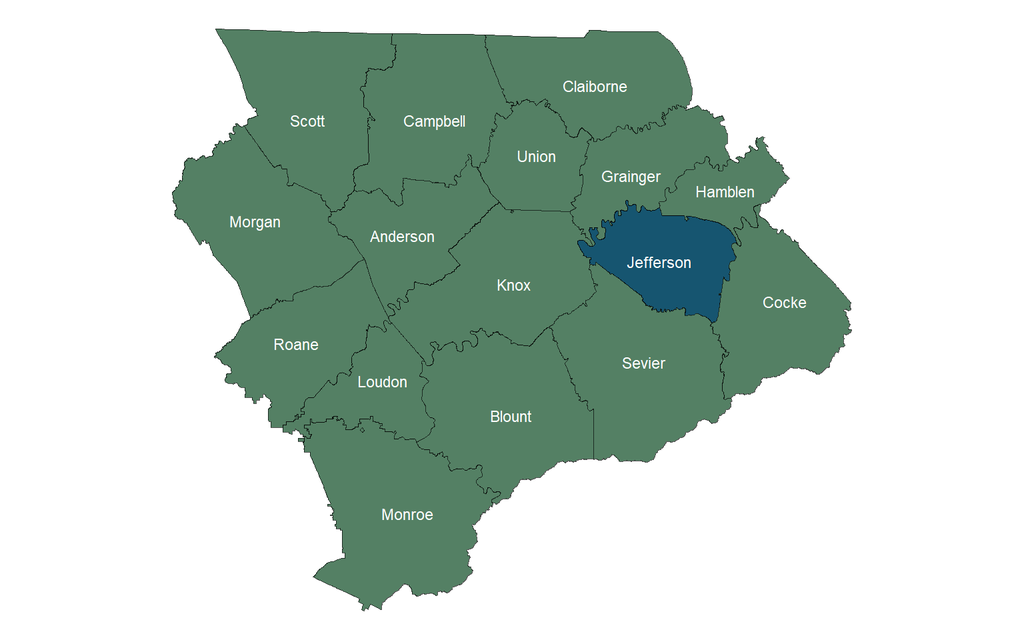

**Population and Growth**

| Place | 1970 | 1980 | 1990 | 2000 | 2010 | 2020 | Change 1970-1980 | Change 1980-1990 | Change 1990-2000 | Change 2000-2010 | Change 2010-2020 |
| --- | --- | --- | --- | --- | --- | --- | --- | --- | --- | --- | --- |
| Jefferson County | 24940 | 31284 | 33016 | 44294 | 51407 | 54683 | 6344 | 1732 | 11278 | 7113 | 3276 |
| Baneberry |  |  | 218 | 366 | 482 | 523 |  |  | 148 | 116 | 41 |
| Dandridge | 1270 | 1383 | 1540 | 2078 | 2812 | 3344 | 113 | 157 | 538 | 734 | 532 |
| Jefferson City | 5124 | 5612 | 5494 | 7760 | 8047 | 8419 | 488 | -118 | 2266 | 287 | 372 |
| New Market |  | 1216 | 1086 | 1234 | 1334 | 1349 |  | -130 | 148 | 100 | 15 |
| White Pine | 1532 | 1900 | 1771 | 1997 | 2196 | 2471 | 368 | -129 | 226 | 199 | 275 |

[interactive chart not shown]

IPUMS NHGIS, University of Minnesota, www.nhgis.org

**Population Density**

| Place | Area | Population Density |
| --- | --- | --- |
| Jefferson County | 314.2652206304219 | 174.0027098458585 |
| Baneberry | 1.780955234824622 | 293.6626310270521 |
| Dandridge | 6.475842809133909 | 516.3806624959188 |
| Jefferson City | 6.758405065981073 | 1245.708109799108 |
| New Market | 4.232277885864865 | 318.7408852583724 |
| White Pine | 2.747089975740158 | 899.4972941627911 |

[interactive chart not shown]

source: U. S. Census Bureau *Decennial Census: Redistricting Data (PL 94-171)*, 2020, accessed June 2, 2026, http://api.census.gov/data/2020/dec/pl.

**Population Descriptions**

| Place | Year | Race Category | Number of People | Percentage of People |
| --- | --- | --- | --- | --- |
| Jefferson County | 2020 | Black | 802 | 0.01132944384014466 |
| Jefferson County | 2020 | Other | 4320 | 0.06102643066013081 |
| Jefferson County | 2020 | White | 49561 | 0.700122900450635 |
| Baneberry | 2020 | Black | 1 | 1.412648857873398e-05 |
| Baneberry | 2020 | Other | 21 | 0.0002966562601534137 |
| Baneberry | 2020 | White | 501 | 0.007077370777945726 |
| Dandridge | 2020 | Black | 106 | 0.001497407789345802 |
| Dandridge | 2020 | Other | 240 | 0.003390357258896156 |
| Dandridge | 2020 | White | 2998 | 0.04235121275904449 |
| Jefferson City | 2020 | Black | 309 | 0.004365084970828801 |

[output cut: 8 more lines]

| Place | Sex | Age Range | Year | Number of People | Percentage of People |
| --- | --- | --- | --- | --- | --- |
| Jefferson County | Female | 10 to 14 years | 2020 | 1352 | 0.01929086109723907 |
| Jefferson County | Female | 15 to 19 years | 2020 | 1712 | 0.02442748091603053 |
| Jefferson County | Female | 20 to 24 years | 2020 | 1678 | 0.02394235571092245 |
| Jefferson County | Female | 25 to 29 years | 2020 | 1525 | 0.02175929228793608 |
| Jefferson County | Female | 30 to 34 years | 2020 | 1365 | 0.01947635014625098 |
| Jefferson County | Female | 35 to 39 years | 2020 | 1524 | 0.02174502389955055 |
| Jefferson County | Female | 40 to 44 years | 2020 | 1607 | 0.02292930013554969 |
| Jefferson County | Female | 45 to 49 years | 2020 | 1838 | 0.02622529785260755 |
| Jefferson County | Female | 5 to 9 years | 2020 | 1586 | 0.02262966397945352 |
| Jefferson County | Female | 50 to 54 years | 2020 | 2028 | 0.0289362916458586 |

[output cut: 206 more lines]

[interactive chart not shown]

source: U. S. Census Bureau *Decennial Census: Redistricting Data (PL 94-171)*, 2020, accessed June 2, 2026, http://api.census.gov/data/2020/dec/pl.

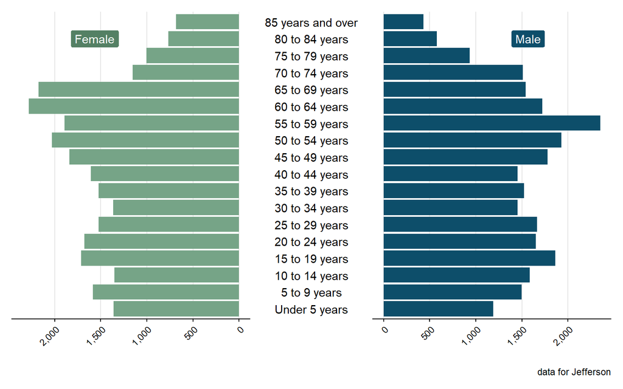

source: U. S. Census Bureau *American Community Survey 5-Year Estimates: Comparison Profiles 5-Year*, 2020, accessed June 2, 2026, http://api.census.gov/data/2020/acs/acs5.

**Education**

| Place | Level of Education | Year | Number of People | Percentage of People |
| --- | --- | --- | --- | --- |
| Jefferson County | 9th to 12th Grade, No Diploma | 2010 | 4184 | 0.0966437992285127 |
| Jefferson County | Associate's degree | 2010 | 2661 | 0.061464901947197 |
| Jefferson County | Bachelor's degree | 2010 | 2827 | 0.06529924006190377 |
| Jefferson County | Graduate or Professional Degree | 2010 | 1793 | 0.04141547132330862 |
| Jefferson County | Less Than 9th Grade | 2010 | 2856 | 0.06596909431085857 |
| Jefferson County | Some College, No Degree | 2010 | 7135 | 0.1648072436652577 |
| Jefferson County | Total | 2010 | 34224 | 0.7905204074561707 |
| Jefferson County | 9th to 12th Grade, No Diploma | 2020 | 2614 | 0.05316033515008541 |
| Jefferson County | Associate's degree | 2020 | 3101 | 0.06306434556251525 |
| Jefferson County | Bachelor's degree | 2020 | 4244 | 0.08630928170503539 |

[output cut: 74 more lines]

[interactive chart not shown]

source: U. S. Census Bureau *American Community Survey 5-Year Estimates: Comparison Profiles 5-Year*, 2020, accessed June 2, 2026, http://api.census.gov/data/2020/acs/acs5.

**Housing Units by Year of Construction**

| Place | Year | 1939 or earlier | 1940-1959 | 1960-1979 | 1980 to 1989 | 1990 to 1999 | 2000 to 2004 | 2005 or later | 2000 to 2009 | 2010 or later | Total |
| --- | --- | --- | --- | --- | --- | --- | --- | --- | --- | --- | --- |
| Jefferson County | 2010 | 1568 | 2231 | 5313 | 3803 | 6122 | 2787 | 1205 |  |  | 23029 |
| Jefferson County | 2020 | 1785 | 2343 | 4805 | 3744 | 5959 |  |  | 4111 | 1606 | 24353 |
| Baneberry | 2010 | 0 | 10 | 43 | 91 | 73 | 38 | 17 |  |  | 272 |
| Dandridge | 2010 | 107 | 96 | 311 | 86 | 230 | 115 | 123 |  |  | 1068 |
| Jefferson City | 2010 | 231 | 548 | 992 | 480 | 664 | 154 | 115 |  |  | 3184 |
| New Market | 2010 | 85 | 91 | 174 | 61 | 81 | 19 | 13 |  |  | 524 |
| White Pine | 2010 | 159 | 186 | 213 | 187 | 120 | 45 | 9 |  |  | 919 |
| Baneberry | 2020 | 0 | 0 | 38 | 65 | 63 |  |  | 55 | 24 | 245 |
| Dandridge | 2020 | 102 | 164 | 338 | 93 | 223 |  |  | 256 | 111 | 1287 |
| Jefferson City | 2020 | 153 | 567 | 731 | 715 | 740 |  |  | 208 | 113 | 3227 |

[output cut: 2 more lines]

[interactive chart not shown]

source: U. S. Census Bureau *Decennial Census: Redistricting Data (PL 94-171)*, 2020, accessed June 2, 2026, http://api.census.gov/data/2020/dec/pl.

**Housing Units by Type of Tenure**

| Place | Year | Own | Rent | Total |
| --- | --- | --- | --- | --- |
| Jefferson County | 2010 | 14663 | 4934 | 19597 |
| Jefferson County | 2020 | 15174 | 4864 | 20038 |
| Baneberry | 2010 | 138 | 69 | 207 |
| Dandridge | 2010 | 668 | 211 | 879 |
| Jefferson City | 2010 | 1401 | 1511 | 2912 |
| New Market | 2010 | 392 | 100 | 492 |
| White Pine | 2010 | 550 | 281 | 831 |
| Baneberry | 2020 | 206 | 16 | 222 |
| Dandridge | 2020 | 870 | 295 | 1165 |
| Jefferson City | 2020 | 1290 | 1476 | 2766 |

[output cut: 2 more lines]

[interactive chart not shown]

source: U. S. Census Bureau *Decennial Census: Redistricting Data (PL 94-171)*, 2020, accessed June 2, 2026, http://api.census.gov/data/2020/dec/pl.

**Income Comparison**

| Place | Year | Median Family Income | Median Household Income | Per Capita Income |
| --- | --- | --- | --- | --- |
| Jefferson County | 2020 | 61416 | 51899 | 25857 |
| Baneberry | 2020 | 101964 | 88500 | 40842 |
| Dandridge | 2020 | 60306 | 48781 | 29358 |
| Jefferson City | 2020 | 54714 | 43158 | 18090 |
| New Market | 2020 | 67361 | 58000 | 29570 |
| White Pine | 2020 | 58854 | 49091 | 22645 |

[interactive chart not shown]

source: U. S. Census Bureau *Decennial Census: Redistricting Data (PL 94-171)*, 2020, accessed June 2, 2026, http://api.census.gov/data/2020/dec/pl.

**Povery Status**

| Place | Year | Above Poverty | Below Poverty |
| --- | --- | --- | --- |
| Jefferson County | 2020 | 13007 | 1489 |
| Baneberry | 2020 | 176 | 1 |
| Dandridge | 2020 | 735 | 52 |
| Jefferson City | 2020 | 1418 | 366 |
| New Market | 2020 | 405 | 30 |
| White Pine | 2020 | 577 | 82 |

[interactive chart not shown]

source: U. S. Census Bureau *American Community Survey 5-Year Estimates: Comparison Profiles 5-Year*, 2020, accessed June 2, 2026, http://api.census.gov/data/2020/acs/acs5.

**Poverty Status by Family Type**

| Place | Poverty Status | Family Type | Number of Families | Year | Percentage of Families |
| --- | --- | --- | --- | --- | --- |
| Jefferson County | Above Poverty | All Families | 13007 | 2020 | 0.7092921801723198 |
| Jefferson County | Above Poverty | Female Householder | 1296 | 2020 | 0.07067291962046025 |
| Jefferson County | Above Poverty | Female Householder with related children | 564 | 2020 | 0.0307558076126077 |
| Jefferson County | Below Poverty | All Families | 1489 | 2020 | 0.08119751336023558 |
| Jefferson County | Below Poverty | Female Householder | 744 | 2020 | 0.04057149089322718 |
| Jefferson County | Below Poverty | Female Householder with related children | 566 | 2020 | 0.03086487076017014 |
| Baneberry | Above Poverty | All Families | 176 | 2020 | 0.009597556985494601 |
| Baneberry | Above Poverty | Female Householder | 8 | 2020 | 0.0004362525902497546 |
| Baneberry | Above Poverty | Female Householder with related children | 6 | 2020 | 0.000327189442687316 |
| Baneberry | Below Poverty | All Families | 1 | 2020 | 5.453157378121933e-05 |

[output cut: 26 more lines]

[interactive chart not shown]

source: U. S. Census Bureau *American Community Survey 5-Year Estimates: Comparison Profiles 5-Year*, 2020, accessed June 2, 2026, http://api.census.gov/data/2020/acs/acs5.

**Employment by Industry**

[output not shown]

[output cut: 56 more lines]

[interactive chart not shown]

source: U. S. Census Bureau *American Community Survey 5-Year Estimates: Comparison Profiles 5-Year*, 2020, accessed June 2, 2026, http://api.census.gov/data/2020/acs/acs5.

**Employment by Industry (Historical)**

| Place | Year | Industry | Number of Jobs | Percentage of Jobs |
| --- | --- | --- | --- | --- |
| Baneberry | 2010 | Agriculture, Forestry, Fishing And Hunting, And Mining | 0 | 0 |
| Baneberry | 2010 | Construction | 12 | 0.0004197271773347324 |
| Baneberry | 2010 | Manufacturing | 49 | 0.001713885974116824 |
| Baneberry | 2010 | Other | 15 | 0.0005246589716684155 |
| Baneberry | 2010 | Professional Services | 63 | 0.002203567681007345 |
| Baneberry | 2010 | Public Administration | 5 | 0.0001748863238894718 |
| Baneberry | 2010 | Trade, Finance, Insurance &amp; Real Estate | 106 | 0.003707590066456803 |
| Baneberry | 2020 | Agriculture, Forestry, Fishing And Hunting, And Mining | 2 | 6.505122784192551e-05 |
| Baneberry | 2020 | Construction | 13 | 0.0004228329809725158 |
| Baneberry | 2020 | Manufacturing | 21 | 0.0006830378923402179 |

[output cut: 74 more lines]

**Labor Force by Place of Work**

| Place | Year | Work Out Of State | Work Out of County of Residence | Work in County of Residence |
| --- | --- | --- | --- | --- |
| Jefferson County | 2020 | 340 | 12768 | 10171 |
| Baneberry | 2020 | 10 | 131 | 93 |
| Dandridge | 2020 | 22 | 582 | 614 |
| Jefferson City | 2020 | 18 | 1039 | 2233 |
| New Market | 2020 | 7 | 332 | 489 |
| White Pine | 2020 | 5 | 553 | 428 |

[interactive chart not shown]

source: U. S. Census Bureau *American Community Survey 5-Year Estimates: Comparison Profiles 5-Year*, 2020, accessed June 2, 2026, http://api.census.gov/data/2020/acs/acs5.

**Commuting Patterns**

| Home County | Year | Number of Jobs | Percentage of Jobs |
| --- | --- | --- | --- |
| Jefferson | 2010 | 4794 | 0.1974708571899328 |
| Jefferson | 2020 | 4776 | 0.1967294146723236 |
| Hamblen | 2020 | 1812 | 0.07463854677266549 |
| Hamblen | 2010 | 1471 | 0.06059233018906784 |
| Knox | 2020 | 1407 | 0.05795609012645714 |
| Knox | 2010 | 1088 | 0.04481608106438192 |
| Sevier | 2020 | 619 | 0.02549738435556288 |
| Sevier | 2010 | 596 | 0.02454998558306216 |
| Blount | 2020 | 185 | 0.007620381430984059 |
| Blount | 2010 | 144 | 0.005931540140874078 |

[output cut: 3 more lines]

| Work County | Year | Number of Jobs | Percentage of Jobs |
| --- | --- | --- | --- |
| Knox | 2020 | 4900 | 0.2018371297936318 |
| Knox | 2010 | 4800 | 0.1977180046958026 |
| Jefferson | 2010 | 4794 | 0.1974708571899328 |
| Jefferson | 2020 | 4776 | 0.1967294146723236 |
| Hamblen | 2020 | 3291 | 0.1355604069695597 |
| Sevier | 2020 | 3126 | 0.1287638505581415 |
| Hamblen | 2010 | 2901 | 0.1194958190880257 |
| Sevier | 2010 | 2149 | 0.08851999835234996 |
| Cocke | 2010 | 567 | 0.02335543930469168 |
| Cocke | 2020 | 558 | 0.02298471804588705 |

[output cut: 3 more lines]

[interactive chart not shown]

source: U. S. Census Bureau *Tn_od_main_JT00_2020*, LEHD Origin-Destination Employment Statistics, 8.3, 2020, accessed June 2, 2026, https://lehd.ces.census.gov/data/lodes/.

## References

Bureau, U. S. Census. *American Community Survey 5-Year Estimates: Comparison Profiles 5-Year*. 2020. Accessed June 2, 2026. http://api.census.gov/data/2020/acs/acs5.

Bureau, U. S. Census. *Decennial Census: Redistricting Data (PL 94-171)*. 2020. Accessed June 2, 2026. http://api.census.gov/data/2020/dec/pl.

Bureau, U. S. Census. *Tn_od_main_JT00_2020*. LEHD Origin-Destination Employment Statistics, 8.3. 2020. Accessed June 2, 2026. https://lehd.ces.census.gov/data/lodes/.